# Multiple Linear Regression

Caijun Qin

28/04/2021

## North Carolina Births

This is the same data we used for Lab 4. In 2004, the state of North Carolina released to the public a large data set containing information on births recorded in this state. This data set has been of interest to medical researchers who are studying the relation between habits and practices of expectant mothers and the birth of their children. We will work with a sample of observations from this data set. These cases were chosen at random.

We have observations on 13 different variables, some categorical and some numerical. The meaning of each variable is as follows.

We will try to fit a model where the response variable is the birth weight in pounds `weight`. We are interested in identifying the best predictors among the other available variables. In this case, we will exclude the variable `fage` from the analysis as it contains a large quantity of missing values.

Let’s load the `nc` data set into our workspace, remove the `fage` variable and exclude records with missing values.

```r
nc <- read.csv("nc.csv", header=TRUE)

# remove first column, 'fage' variable
nc <- nc[,-1]

# remove records with missing values
nc <- na.omit(nc)
dim(nc)
```

```
## [1] 962  12
```

```r
attach(nc)

# column names of nc
cols <- colnames(x = nc)

# converting all character(string) columns into factor columns
for (idx in 1:length(nc)) {
  if(assertthat::are_equal(typeof(nc[1, idx]), "character")) {
    eval(expr = parse(text =  paste("nc$", cols[idx], " <- as.factor(x = nc$", cols[idx], ")")))
  }
}

str(object = nc)
```

```
## 'data.frame':    962 obs. of  12 variables:
##  $ mage          : int  13 14 15 15 15 15 15 15 16 16 ...
##  $ mature        : Factor w/ 2 levels "mature mom","younger mom": 2 2 2 2 2 2 2 2 2 2 ...
##  $ weeks         : int  39 42 37 41 39 38 37 35 37 45 ...
##  $ premie        : Factor w/ 2 levels "full term","premie": 1 1 1 1 1 1 1 2 1 1 ...
##  $ visits        : int  10 15 11 6 9 19 12 5 13 9 ...
##  $ marital       : Factor w/ 2 levels "married","not married": 1 1 1 1 1 1 1 1 1 1 ...
##  $ gained        : int  38 20 38 34 27 22 76 15 52 28 ...
##  $ weight        : num  7.63 7.88 6.63 8 6.38 5.38 8.44 4.69 6.94 7.44 ...
##  $ lowbirthweight: Factor w/ 2 levels "low","not low": 2 2 2 2 2 1 2 1 2 2 ...
##  $ gender        : Factor w/ 2 levels "female","male": 2 2 1 2 1 2 2 2 1 2 ...
##  $ habit         : Factor w/ 2 levels "nonsmoker","smoker": 1 1 1 1 1 1 1 1 1 1 ...
##  $ whitemom      : Factor w/ 2 levels "not white","white": 1 1 2 2 1 1 1 1 2 2 ...
##  - attr(*, "na.action")= 'omit' Named int [1:37] 9 51 57 64 65 73 103 141 186 212 ...
##   ..- attr(*, "names")= chr [1:37] "9" "51" "57" "64" ...
```

```r
nc
```

```
##     mage      mature weeks    premie visits     marital gained weight
## 1     13 younger mom    39 full term     10     married     38   7.63
## 2     14 younger mom    42 full term     15     married     20   7.88
## 3     15 younger mom    37 full term     11     married     38   6.63
## 4     15 younger mom    41 full term      6     married     34   8.00
## 5     15 younger mom    39 full term      9     married     27   6.38
## 6     15 younger mom    38 full term     19     married     22   5.38
## 7     15 younger mom    37 full term     12     married     76   8.44
## 8     15 younger mom    35    premie      5     married     15   4.69
## 10    16 younger mom    37 full term     13     married     52   6.94
## 11    16 younger mom    45 full term      9     married     28   7.44
## 12    16 younger mom    42 full term      8     married     34   8.81
## 13    16 younger mom    40 full term      4     married     12   6.00
## 14    16 younger mom    38 full term     12     married     30   7.13
## 15    16 younger mom    38 full term     15     married     75   7.56
```

[output cut: 1911 more lines]

```r
# Importing required libraries
pkgs <- c("comprehenr", "leaps", "olsrr")
install.packages(pkgs, repos = "http://cran.us.r-project.org")
lapply(pkgs, require, character.only = TRUE)
```

```
## [[1]]
## [1] TRUE
##
## [[2]]
## [1] TRUE
##
## [[3]]
## [1] TRUE
```

## Homework - Due on Wednesday, April 28 by 2pm

1. Explore the data and identify which predictors you would include in the model. Look for possible issues with collinearity. Are there any variables you woud not include? Explain. (hint: notice that the `mature` variable is simply a categorization of the variable `mage`. Hence, we only include `mage` because it contains more information. Check for similar patterns with other variables and exclude them form the analysis. You should end up with 8 predictors in the initial model.)

**Resp:** Several steps have been sequentially taken to arrive at the final model. Initially, the full model with each available coefficient was constructed and summarized. The features {`mage`, `weeks`, `gained`, `lowbirthweight`, `gender`, `habit`, `whitemom`} were the first to be considered after each achieving a p-value of less than 10%, denoted by the column `Pr(>|t|)` in the summary of the full model. Note that `lowbirthweight` is a categorization of `weight` similar to `mage` and `maturity`, so `lowbirthweight` was left out. The next variance inflation factor (VIF) was computed for each feature in the full model to see if any extreme collinearity exists. Since all features have a VIF of <4, the typical threshold to call for further investigation, no features were immediately dropped. The highest VIF of 2.439011 belongs to `weeks`. However, it is understandable that units of time are usually uncontrolled and are used almost always as an independent variable. As time goes on, other features will show trends, hence the hint of collinearity. Taking a look at the facet grid of plotting variables pairwise, the currently used variables do not show any clear collinearity amongst each other.

```r
head(x = nc)
```

```
##   mage      mature weeks    premie visits marital gained weight lowbirthweight
## 1   13 younger mom    39 full term     10 married     38   7.63        not low
## 2   14 younger mom    42 full term     15 married     20   7.88        not low
## 3   15 younger mom    37 full term     11 married     38   6.63        not low
## 4   15 younger mom    41 full term      6 married     34   8.00        not low
## 5   15 younger mom    39 full term      9 married     27   6.38        not low
## 6   15 younger mom    38 full term     19 married     22   5.38            low
##   gender     habit  whitemom
## 1   male nonsmoker not white
## 2   male nonsmoker not white
## 3 female nonsmoker     white
## 4   male nonsmoker     white
## 5 female nonsmoker not white
## 6   male nonsmoker not white
```

```r
# Pairwise simple linear regression plots
cat("Pairwise plot between parameters:\n")
```

```
## Pairwise plot between parameters:
```

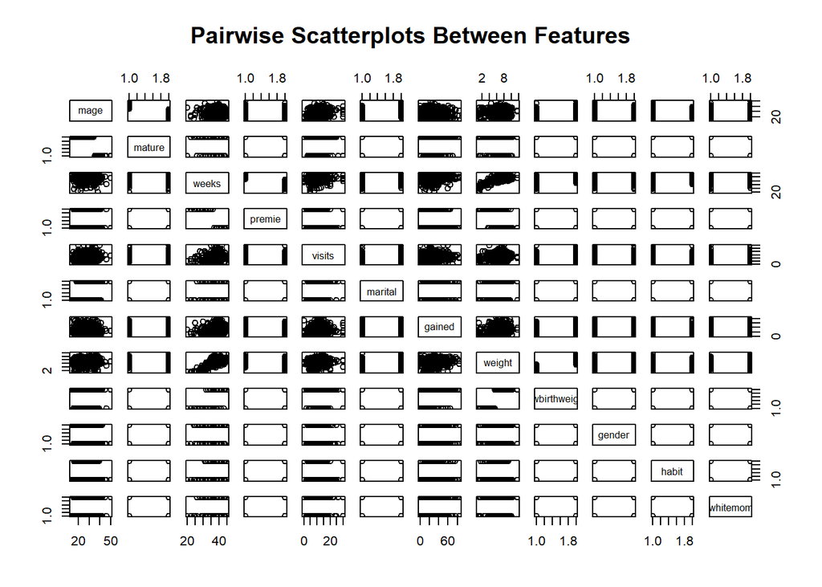

```r
plot(nc, main = "Pairwise Scatterplots Between Features")
```

```r
# Defining the full model
nc.formula <- weight ~ mage + weeks + premie + visits + marital + gained + lowbirthweight + gender + habit + whitemom
nc.lm <- lm(formula = nc.formula, data = nc)

# Coefficient diagnostics
cat("summary of full model:\n")
```

```
## summary of full model:
```

```r
nc.summary_initial <- summary(object = nc.lm)
nc.summary_initial
```

```
##
## Call:
## lm(formula = nc.formula, data = nc)
##
## Residuals:
##     Min      1Q  Median      3Q     Max
## -2.4513 -0.6089 -0.0232  0.5465  3.9600
##
## Coefficients:
##                        Estimate Std. Error t value Pr(>|t|)
## (Intercept)           -2.862049   0.631097  -4.535 6.49e-06 ***
## mage                   0.008817   0.005312   1.660  0.09726 .
## weeks                  0.186316   0.016097  11.575  < 2e-16 ***
## premiepremie          -0.027597   0.124464  -0.222  0.82458
## visits                -0.002562   0.007793  -0.329  0.74247
## maritalnot married     0.106796   0.071484   1.494  0.13551
## gained                 0.006706   0.002089   3.209  0.00138 **
## lowbirthweightnot low  2.296152   0.118946  19.304  < 2e-16 ***
## gendermale             0.377310   0.058648   6.434 1.97e-10 ***
## habitsmoker           -0.266027   0.089318  -2.978  0.00297 **
## whitemomwhite          0.218515   0.069194   3.158  0.00164 **
## ---
## Signif. codes:  0 '***' 0.001 '**' 0.01 '*' 0.05 '.' 0.1 ' ' 1
##
## Residual standard error: 0.9041 on 951 degrees of freedom
## Multiple R-squared:  0.6266, Adjusted R-squared:  0.6227
## F-statistic: 159.6 on 10 and 951 DF,  p-value: < 2.2e-16
```

```r
# Computing VIF scores
ols_vif_tol(nc.lm)
```

```
##                Variables Tolerance      VIF
## 1                   mage 0.7879196 1.269165
## 2                  weeks 0.4100022 2.439011
## 3           premiepremie 0.4333983 2.307346
## 4                 visits 0.9166108 1.090976
## 5     maritalnot married 0.7076933 1.413041
## 6                 gained 0.9643544 1.036963
## 7  lowbirthweightnot low 0.6335725 1.578351
## 8             gendermale 0.9881224 1.012020
## 9            habitsmoker 0.9685750 1.032445
## 10         whitemomwhite 0.8750504 1.142791
```

```r
# Best models based on number of coefficients kept
nc.leaps <- regsubsets(x = nc.formula, data = nc, nbest = 10)
summary(nc.leaps)
```

```
## Subset selection object
## Call: regsubsets.formula(x = nc.formula, data = nc, nbest = 10)
## 10 Variables  (and intercept)
##                       Forced in Forced out
## mage                      FALSE      FALSE
## weeks                     FALSE      FALSE
## premiepremie              FALSE      FALSE
## visits                    FALSE      FALSE
## maritalnot married        FALSE      FALSE
## gained                    FALSE      FALSE
## lowbirthweightnot low     FALSE      FALSE
## gendermale                FALSE      FALSE
## habitsmoker               FALSE      FALSE
## whitemomwhite             FALSE      FALSE
## 10 subsets of each size up to 8
```

[output cut: 163 more lines]

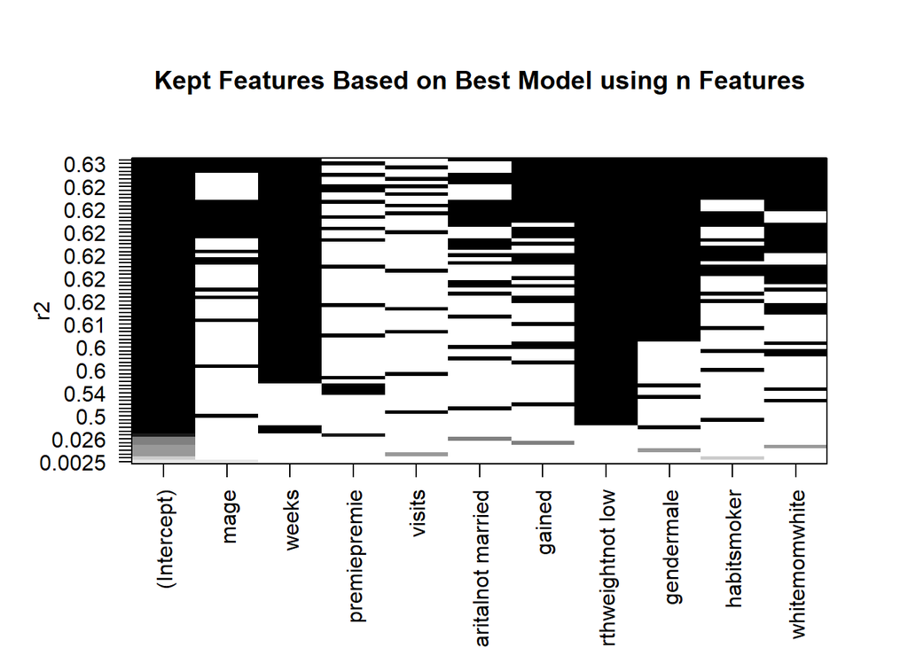

```r
plot(nc.leaps, main = "Kept Features Based on Best Model using n Features", xlabel = "Features", ylabel = "R^2", scale = "r2")
```

2. Fit a model including all the variables you chose in question 1 (please fit an additive model i.e no interaction terms). What percentage of variation in birth weight is explained by the model? Is this a good model? Explain.

**Resp:** With an `R^2` (ratio of SSR to SSTO) of 0.465, barely half of the results in `weight` could be explained by the additive model using the previously selected features. Since less than half the variance in `weight` is explained by the additive components of the model, this model does not have particularly trustworthy prediction ability.

```r
nc.formula_final <- weight ~ mage + weeks + gained + gender + habit + whitemom
nc.lm_final <- lm(formula = nc.formula_final, data = nc)
summary(nc.lm_final)
```

```
##
## Call:
## lm(formula = nc.formula_final, data = nc)
##
## Residuals:
##     Min      1Q  Median      3Q     Max
## -3.7331 -0.6282 -0.0032  0.6756  3.9853
##
## Coefficients:
##                Estimate Std. Error t value Pr(>|t|)
## (Intercept)   -6.563932   0.505709 -12.980  < 2e-16 ***
## mage           0.014012   0.005752   2.436 0.015041 *
## weeks          0.330486   0.012379  26.697  < 2e-16 ***
## gained         0.009424   0.002468   3.818 0.000143 ***
## gendermale     0.388681   0.069589   5.585 3.04e-08 ***
## habitsmoker   -0.400475   0.105616  -3.792 0.000159 ***
## whitemomwhite  0.272585   0.078901   3.455 0.000575 ***
## ---
## Signif. codes:  0 '***' 0.001 '**' 0.01 '*' 0.05 '.' 0.1 ' ' 1
##
## Residual standard error: 1.077 on 955 degrees of freedom
## Multiple R-squared:  0.4683, Adjusted R-squared:  0.465
## F-statistic: 140.2 on 6 and 955 DF,  p-value: < 2.2e-16
```

3. Are there any predictors that are not significant? Is the saturated model with all the predictors the best model? Use backward elimination to find the best model i.e take not significant variables out one at a time (take the variable with highest t-test p-value out first). Justify the choice of your final model both based on the adjusted R-squared and a formal test. (hint: use `anova` to compare models and make your final decision).

**Resp:** There `visits`, `premie`, and `marital` has the top p-values out of all variables. With an adjusted R^2 of 0.06785, the reduced model from backward elimination could not match the currently used final model. Note that the backward elimination produced a formula with one less variable in the model, which may partly explain such a decrease in adjusted R^2. To recall, the current best model has 6 variables and holds an adjusted R^2 value of 0.465. The p-value for the F-statistic from comparing the two models is 2.2e-16, which clearly indicates that the full model (current one) should be used still. The residual sum of squares (RSS) are 1106.8 and 1930.4, respectively, with the lower number belonging to the current model. This further verifies the better prediction ability of the current model relative to the backward elimination-derived one.

```r
# Full model diagnostics (every feature is included)
nc.summary_initial
```

```
##
## Call:
## lm(formula = nc.formula, data = nc)
##
## Residuals:
##     Min      1Q  Median      3Q     Max
## -2.4513 -0.6089 -0.0232  0.5465  3.9600
##
## Coefficients:
##                        Estimate Std. Error t value Pr(>|t|)
## (Intercept)           -2.862049   0.631097  -4.535 6.49e-06 ***
## mage                   0.008817   0.005312   1.660  0.09726 .
## weeks                  0.186316   0.016097  11.575  < 2e-16 ***
## premiepremie          -0.027597   0.124464  -0.222  0.82458
## visits                -0.002562   0.007793  -0.329  0.74247
## maritalnot married     0.106796   0.071484   1.494  0.13551
## gained                 0.006706   0.002089   3.209  0.00138 **
## lowbirthweightnot low  2.296152   0.118946  19.304  < 2e-16 ***
## gendermale             0.377310   0.058648   6.434 1.97e-10 ***
## habitsmoker           -0.266027   0.089318  -2.978  0.00297 **
## whitemomwhite          0.218515   0.069194   3.158  0.00164 **
## ---
## Signif. codes:  0 '***' 0.001 '**' 0.01 '*' 0.05 '.' 0.1 ' ' 1
##
## Residual standard error: 0.9041 on 951 degrees of freedom
## Multiple R-squared:  0.6266, Adjusted R-squared:  0.6227
## F-statistic: 159.6 on 10 and 951 DF,  p-value: < 2.2e-16
```

```r
pvalues_initial <- as.vector(x = to_vec(expr = for(i in 1:11) nc.summary_initial$coefficients[i, "Pr(>|t|)"]))
cat("p-values for initial model:\n", pvalues_initial, "\n")
```

```
## p-values for initial model:
##  6.494465e-06 0.0972643 4.436363e-29 0.8245755 0.7424652 0.1355092 0.001375752 2.560411e-70 1.972629e-10 0.00297089 0.001638742
```

```r
# indexes of pvalues_initial ranking from largest (index 1) to smallest (index 11) p-value
pv_idx <- order(pvalues_initial, decreasing = TRUE)
cat("pv_idx:\n", pv_idx, "\n\n")
```

```
## pv_idx:
##  4 5 6 2 10 11 7 1 9 3 8
```

```r
# column names sorted by corresponding p-value descendingly
# redundant variables and weight (mature, weight) also removed
cols_pv_desc <- cols[pv_idx][c(1:3, 5:8)]
cat("cols_pv_desc:\n", cols_pv_desc, "\n\n")
```

```
## cols_pv_desc:
##  premie visits marital gender habit gained mage
```

```r
# backward elimination
best_r2_adj_BW <- 0
best_formulaBW <- NULL
nc.lm_best_BW <- NULL
for (idx in 1:length(x = cols_pv_desc)) {
  formulaBW <-  eval(expr = parse(text = paste("weight ~", paste(cols_pv_desc[3:length(x = cols_pv_desc)], collapse = " + "))))
  nc.lm_BW <- lm(formula = formulaBW, data = nc)
  nc.summary_BW <- summary(object = nc.lm_BW)

  if (nc.summary_BW$adj.r.squared > best_r2_adj_BW) {
    best_r2_adj_BW <- nc.summary_BW$adj.r.squared
    best_formulaBW <- formulaBW
    nc.lm_best_BW <- nc.lm_BW
  }
}

cat("Best model from backward elimination:\n")
```

```
## Best model from backward elimination:
```

```r
nc.lm_best_BW
```

```
##
## Call:
## lm(formula = formulaBW, data = nc)
##
## Coefficients:
##        (Intercept)  maritalnot married          gendermale         habitsmoker
##           6.323745            0.477940            0.412946           -0.339454
##             gained                mage
##           0.014925           -0.004035
```

```r
summary(nc.lm_best_BW)
```

```
##
## Call:
## lm(formula = formulaBW, data = nc)
##
## Residuals:
##     Min      1Q  Median      3Q     Max
## -5.9364 -0.6764  0.1716  0.9036  4.5672
##
## Coefficients:
##                     Estimate Std. Error t value Pr(>|t|)
## (Intercept)         6.323745   0.242260  26.103  < 2e-16 ***
## maritalnot married  0.477940   0.105534   4.529 6.68e-06 ***
## gendermale          0.412946   0.091781   4.499 7.66e-06 ***
## habitsmoker        -0.339454   0.139523  -2.433   0.0152 *
## gained              0.014925   0.003242   4.604 4.71e-06 ***
## mage               -0.004035   0.008286  -0.487   0.6264
## ---
## Signif. codes:  0 '***' 0.001 '**' 0.01 '*' 0.05 '.' 0.1 ' ' 1
##
## Residual standard error: 1.421 on 956 degrees of freedom
## Multiple R-squared:  0.0727, Adjusted R-squared:  0.06785
## F-statistic: 14.99 on 5 and 956 DF,  p-value: 3.452e-14
```

```r
cat("nc.lm_best_BW formula:\n")
```

```
## nc.lm_best_BW formula:
```

```r
best_formulaBW
```

```
## weight ~ marital + gender + habit + gained + mage
```

```r
# comparing original reduced model with backward elimination produced best model
anova(nc.lm_final, nc.lm_best_BW)
```

```
## Analysis of Variance Table
##
## Model 1: weight ~ mage + weeks + gained + gender + habit + whitemom
## Model 2: weight ~ marital + gender + habit + gained + mage
##   Res.Df    RSS Df Sum of Sq      F    Pr(>F)
## 1    955 1106.8
## 2    956 1930.4 -1   -823.58 710.64 < 2.2e-16 ***
## ---
## Signif. codes:  0 '***' 0.001 '**' 0.01 '*' 0.05 '.' 0.1 ' ' 1
```

```r
cat("critical F-value: ", qf(p = 0.95, df1 = 955, df2 = 956), "\n\n")
```

```
## critical F-value:  1.112351
```

4. Ideally we want the regression sum of squares (SS(Regression) in the class notes) to be large relative to the residuals sum of squares (SS(Residuals)). What are the values for SS(Regression) and SS(Residuals) in your final model? (hint: use `anova`).

**Resp:** For the final model, the regression sum of squares is `SSR = 974.9191`, and the residual (error) sum of squares is `SSE = 1106.779`.

```r
nc.summary_final <- summary(object = nc.lm_final)
nc.anova_final <- anova(object = nc.lm_final)
nc.summary_final
```

```
##
## Call:
## lm(formula = nc.formula_final, data = nc)
##
## Residuals:
##     Min      1Q  Median      3Q     Max
## -3.7331 -0.6282 -0.0032  0.6756  3.9853
##
## Coefficients:
##                Estimate Std. Error t value Pr(>|t|)
## (Intercept)   -6.563932   0.505709 -12.980  < 2e-16 ***
## mage           0.014012   0.005752   2.436 0.015041 *
## weeks          0.330486   0.012379  26.697  < 2e-16 ***
## gained         0.009424   0.002468   3.818 0.000143 ***
## gendermale     0.388681   0.069589   5.585 3.04e-08 ***
## habitsmoker   -0.400475   0.105616  -3.792 0.000159 ***
## whitemomwhite  0.272585   0.078901   3.455 0.000575 ***
## ---
## Signif. codes:  0 '***' 0.001 '**' 0.01 '*' 0.05 '.' 0.1 ' ' 1
##
## Residual standard error: 1.077 on 955 degrees of freedom
## Multiple R-squared:  0.4683, Adjusted R-squared:  0.465
## F-statistic: 140.2 on 6 and 955 DF,  p-value: < 2.2e-16
```

```r
nc.anova_final
```

```
## Analysis of Variance Table
##
## Response: weight
##            Df  Sum Sq Mean Sq  F value    Pr(>F)
## mage        1    5.14    5.14   4.4365 0.0354393 *
## weeks       1  887.72  887.72 765.9798 < 2.2e-16 ***
## gained      1   20.23   20.23  17.4598 3.203e-05 ***
## gender      1   32.88   32.88  28.3735 1.248e-07 ***
## habit       1   15.11   15.11  13.0374 0.0003212 ***
## whitemom    1   13.83   13.83  11.9355 0.0005750 ***
## Residuals 955 1106.78    1.16
## ---
## Signif. codes:  0 '***' 0.001 '**' 0.01 '*' 0.05 '.' 0.1 ' ' 1
```

```r
SSTO <- var(x = nc$weight) * (nrow(x = nc) - 1)
cat("SSTO: ", SSTO, "\n")
```

```
## SSTO:  2081.698
```

```r
SSE <- nc.anova_final[7, 2]
cat("SSE: ", SSE, "\n")
```

```
## SSE:  1106.779
```

```r
SSR <- SSTO - SSE
cat("SSR: ", SSR, "\n")
```

```
## SSR:  974.9191
```

5. Is there real predicitve value in the independent variables that you chose? That is, test the hypothesis that all the slopes are zero (hint: check the F-statistic and its p-value). What is the rejection region for this test using a 5% significance level?

```r
nc.summary_final
```

```
##
## Call:
## lm(formula = nc.formula_final, data = nc)
##
## Residuals:
##     Min      1Q  Median      3Q     Max
## -3.7331 -0.6282 -0.0032  0.6756  3.9853
##
## Coefficients:
##                Estimate Std. Error t value Pr(>|t|)
## (Intercept)   -6.563932   0.505709 -12.980  < 2e-16 ***
## mage           0.014012   0.005752   2.436 0.015041 *
## weeks          0.330486   0.012379  26.697  < 2e-16 ***
## gained         0.009424   0.002468   3.818 0.000143 ***
## gendermale     0.388681   0.069589   5.585 3.04e-08 ***
## habitsmoker   -0.400475   0.105616  -3.792 0.000159 ***
## whitemomwhite  0.272585   0.078901   3.455 0.000575 ***
## ---
## Signif. codes:  0 '***' 0.001 '**' 0.01 '*' 0.05 '.' 0.1 ' ' 1
##
## Residual standard error: 1.077 on 955 degrees of freedom
## Multiple R-squared:  0.4683, Adjusted R-squared:  0.465
## F-statistic: 140.2 on 6 and 955 DF,  p-value: < 2.2e-16
```

```r
nc.anova_final
```

```
## Analysis of Variance Table
##
## Response: weight
##            Df  Sum Sq Mean Sq  F value    Pr(>F)
## mage        1    5.14    5.14   4.4365 0.0354393 *
## weeks       1  887.72  887.72 765.9798 < 2.2e-16 ***
## gained      1   20.23   20.23  17.4598 3.203e-05 ***
## gender      1   32.88   32.88  28.3735 1.248e-07 ***
## habit       1   15.11   15.11  13.0374 0.0003212 ***
## whitemom    1   13.83   13.83  11.9355 0.0005750 ***
## Residuals 955 1106.78    1.16
## ---
## Signif. codes:  0 '***' 0.001 '**' 0.01 '*' 0.05 '.' 0.1 ' ' 1
```

```r
cat("critical t-value: ", qt(p = 0.05, df = 955, lower.tail = FALSE))
```

```
## critical t-value:  1.646451
```

6. Perform an analysis of residuals. Show the respective plots for the analysis (i.e Q-Q plot and plot of predicted values vs residuals). Are there any extreme violations of the model assumptions? Explain.

**Resp:**  
The QQ plot indicates that the distribution for `weight` may follow a left-skewed Gaussian distribution at best. This violates the assumption that residuals follow a normal distribution.The residuals vs. fitted plot also marks 3 extreme outliers corresponding to indexes of 75, 659, and 667. However, given the tremendous sample size in dataset `nc`, no other outliers suggest that the model fits pretty well. Finally, there is the assumption of homoscedascity. The residuals vs. fitted plot seem to show a small tendency for points to cluster together, leaving lower concentrations of points near the extreme ends. Although the plot is not that evident, variance consistency of residuals across all values taken by the used variables is questionable.

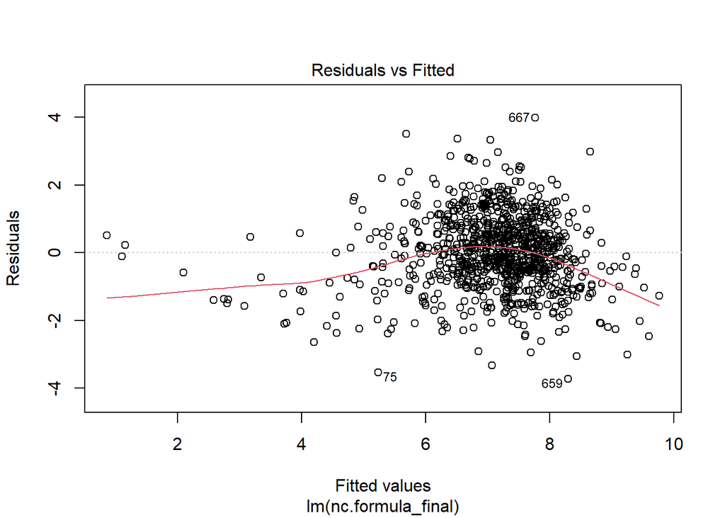

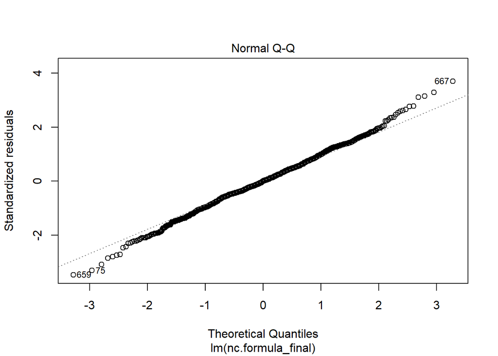

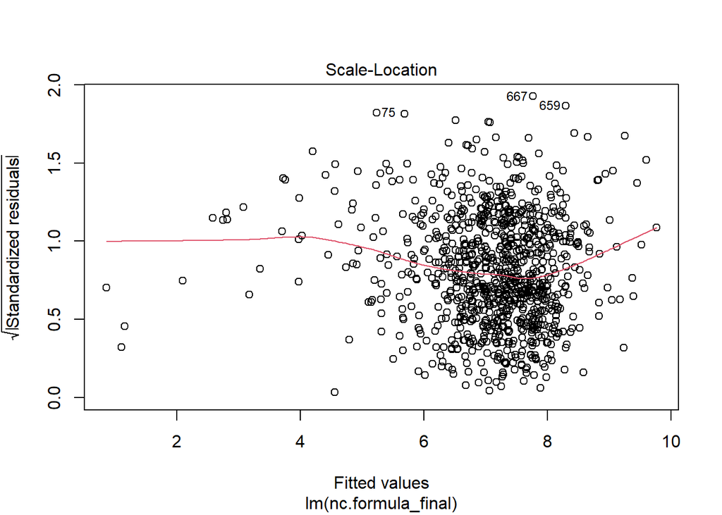

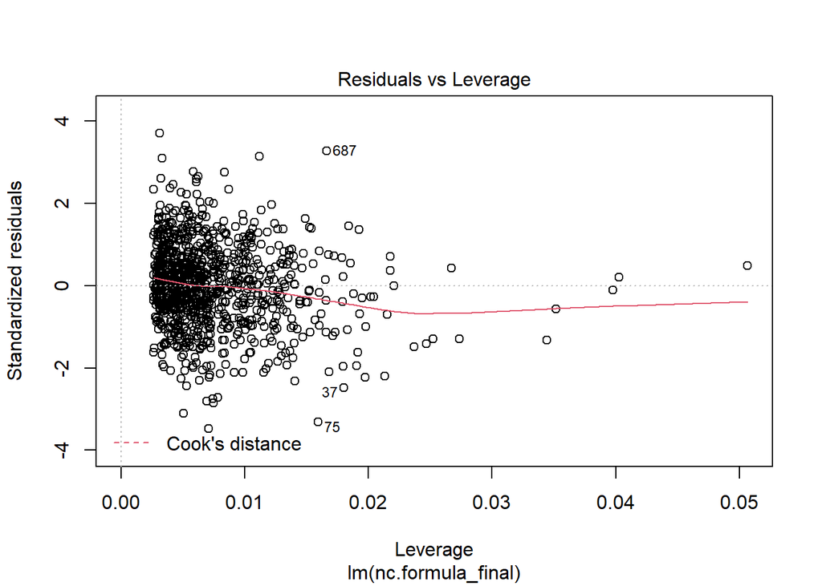

```r
# scroll through each plot
# first and second are wanted
plot(nc.lm_final)
```

7. Provide a short interpretation of the partial slopes of your final model in the context of the problem.

**Resp:** The partial slopes of the final model each indicate how much would the expected value of `weight` change, and in which direction, given 1 unit change in 1 variable only. The corresponding partial slope for each variable represents that change. By absolute value, the variables and their partial slopes that contribute to the vast majority of the change in expected value of `weight` are as follows: `weeks` (0.330486), `gender` (0.388681), `habit` (-0.400475), `whitemom` (0.272585). Notice how `habit`, referring to smoking habit, is the only variable with a negative partial slope. With a 1 indicating a smoker, we expect the birth `weight` to decrease due to harmful effects from smoking. On the other hand, `weeks` is simply time; we expect a baby to grow heavier as time passes. The other indicator variables, which have positive partial slopes, indicate a statistical preference for one gender or ethnicity to associate with heavier weights.